# Data_analysis

## 4. Typology Clusters on PCA

Visualization of PCA by stream Typology

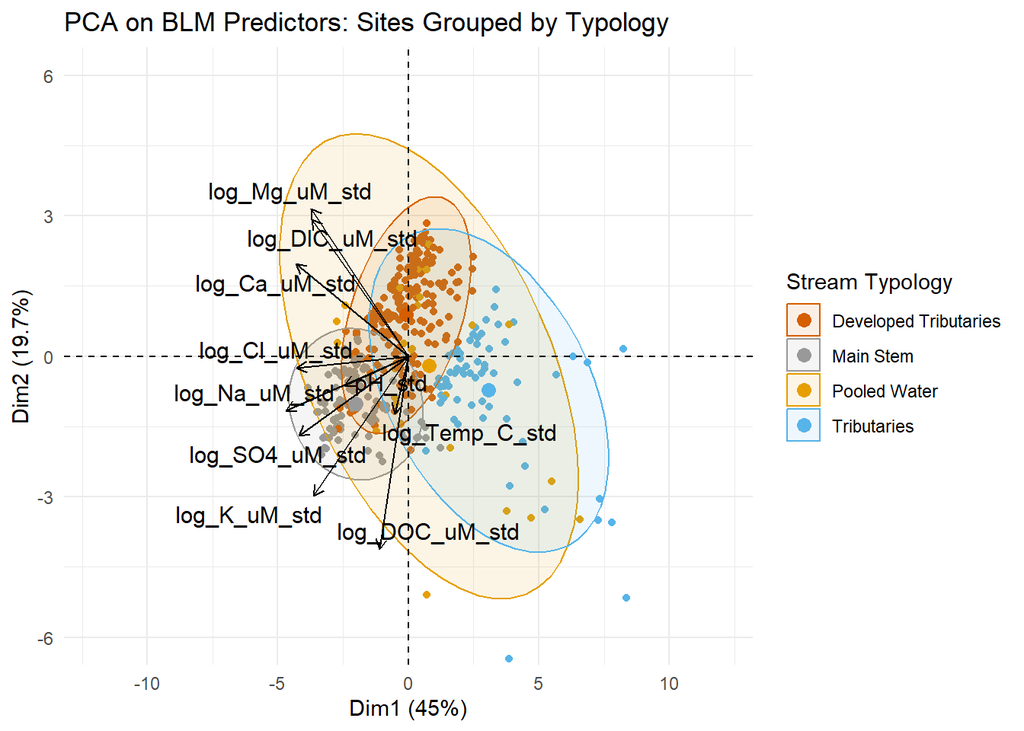

```r
library(factoextra)
library(ggplot2)

# Assign color-blind friendly colors to typologies
typology_colors <- c(
  "Main Stem" = "#999999",
  "Developed Tributaries" = "#D55E00",
  "Tributaries"   = "#56B4E9",
  "Pooled Water" = "#E69F00"
)

#
pca_all_dat <- fviz_pca_biplot(pca_result,
                geom.ind = "point",
                col.ind = dat$Typology,       # color points by Typology
                shape.ind = 16,              # all circles
                addEllipses = TRUE,
                legend.title = "Stream Typology",
                col.var = "black",
                repel = TRUE,
                label = "var"                # label the variables
) +
  scale_color_manual(values = typology_colors) +      # custom colors for points and ellipses
  scale_fill_manual(values = typology_colors) +       # ensures ellipses match same colors
  scale_shape_manual(values = rep(16, length(unique(dat$Typology)))) +
  labs(title = "PCA on BLM Predictors: Sites Grouped by Typology") +
  coord_cartesian(xlim = c(-12, 12), ylim = c(-6, 6)) +
  theme_minimal()

# View
pca_all_dat
```

Save plot

```r
# Define output directory
out_dir <- "Plots by Typology"

# Create folder if it doesn't exist
if (!dir.exists(out_dir)) {
  dir.create(out_dir, recursive = TRUE)
}

# Save plot
ggsave(
  filename = file.path(out_dir, "PCA_by_Typology.png"),
  plot = pca_all_dat,
  width = 8,
  height = 6,
  units = "in",
  dpi = "print"
)
```

## 5. Relative Frequency by Inherent Characteristics

Frequency table by inherent characteristics

```r
library(dplyr)
library(tidyr)

# inherent characteristics
site_char <- c("Regime", "Development")

typology_summary_table_pct <- dat %>%
  dplyr::select(all_of(site_char), Typology) %>%
  pivot_longer(
    cols = -Typology,
    names_to = "Variable",
    values_to = "Value"
  ) %>%
  count(Variable, Typology, Value, name = "Freq") %>%
  group_by(Variable, Typology) %>%
  mutate(RelFreq = prop.table(Freq) * 100)

typology_summary_table_pct
```

| Variable | Typology | Value | Freq | RelFreq |
| --- | --- | --- | --- | --- |
| Development | Developed Tributaries | High | 95 | 51.630435 |
| Development | Developed Tributaries | Low | 50 | 27.173913 |
| Development | Developed Tributaries | Medium | 39 | 21.195652 |
| Development | Main Stem | High | 21 | 19.811321 |
| Development | Main Stem | Low | 22 | 20.754717 |
| Development | Main Stem | Medium | 63 | 59.433962 |
| Development | Pooled Water | High | 12 | 40.000000 |
| Development | Pooled Water | Low | 2 | 6.666667 |
| Development | Pooled Water | Medium | 16 | 53.333333 |
| Development | Tributaries | High | 3 | 4.545455 |

[output cut: 8 more lines]

Now we’ll visualize these as frequency plots of stream inherent characteristics by cluster

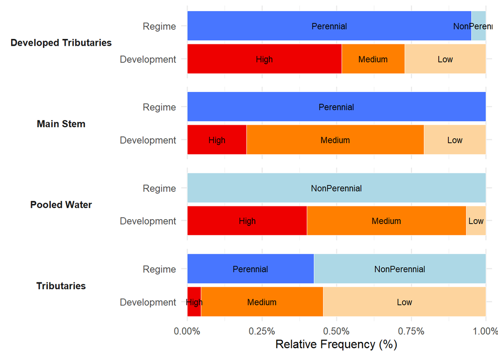

```r
library(ggplot2)
library(dplyr)

# Combine variable and value
typology_summary_table_pct <- typology_summary_table_pct %>%
  mutate(Value_labeled = paste0(Variable, ": ", Value))

# Change the order of Variable Values
typology_summary_table_pct$Value_labeled <- factor( typology_summary_table_pct$Value_labeled, levels = c(

  # Development
  "Development: Low",
  "Development: Medium",
  "Development: High",

  # Regime
  "Regime: NonPerennial",
  "Regime: Perennial" )
  )

# Create a named color vector for all Value_labeled combinations
color_map <- c(
  # Development
  "Development: Low" = "#fdd49e",
  "Development: Medium" = "darkorange1",
  "Development: High" = "red2",

  # Regime
  "Regime: NonPerennial" = "lightblue",
  "Regime: Perennial" = "royalblue1" )

# Plot
rel_freq_typology <- ggplot(
  typology_summary_table_pct,
  aes(y = Variable, x = RelFreq, fill = Value_labeled)
) +
  geom_bar(
    stat = "identity",
    position = "fill",
    color = "white",
    linewidth = 0.2
  ) +

  # --- Add labels INSIDE stacked bars ---
  geom_text(
    aes(label = Value),        # OR use Value_labeled if you want full label
    position = position_fill(vjust = 0.5),
    size = 3,
    color = "black"
  ) +

  facet_wrap(~ Typology, ncol = 1, strip.position = "left") +
  scale_x_continuous(
    labels = scales::percent_format(scale = 1),
    expand = c(0, 0.02)        # expands right side so labels fit
  ) +

  labs(x = "Relative Frequency (%)", y = NULL) +

  theme_minimal(base_size = 12) +
  theme(
    strip.placement = "outside",
    strip.text.y.left = element_text(angle = 0, face = "bold"),
    panel.spacing = unit(0.6, "lines"),
    legend.position = "none"   # <<< REMOVE LEGEND
  ) +

  scale_fill_manual(values = color_map)

rel_freq_typology
```

Save plot

```r
ggsave("Plots by Typology/Relative_Freq_Plot_by_Typologyr.png",
       plot = rel_freq_typology,
       width = 8,
       height = 5,
       units = "in",
       dpi = "print")
```

# Identifying Important Predictors of Bioavailability

To determine the relative importance of each BLM predictor on Zn and Cu bioavailability, we will conduct separate multiple linear regressions (MLR) and use step wise selection of the most important predictors.

```r
library(readxl)

dat <- read_excel("Bioavailability_Master_Spreadsheet_Clean_3.xlsx",
    sheet = "HA 10% Closed System")

head(dat)
```

| Typology | Sample_ID | Site | Date | Regime | Flow_state | Network | Relative_elevation_m | Dist_from_EFPC_km | Drainage_area_km2 | Developed_lulc | Type | Development | Distance_from_EFPC | Drainage_area | Orientation | Relative_elevation | pH | Temp_C | DOC_uM | Ca_uM | Mg_uM | Na_uM | K_uM | SO4_uM | Cl_uM | DIC_uM | Zn_uM | Cu_uM | Free_Zn_M | … |
| --- | --- | --- | --- | --- | --- | --- | --- | --- | --- | --- | --- | --- | --- | --- | --- | --- | --- | --- | --- | --- | --- | --- | --- | --- | --- | --- | --- | --- | --- | --- |
| Developed Tributaries | WaDE_62 | MTN1.1 | 2023-06-23 | NonPerennial | Flowing | MTN | 3.832 | 0.205 | 1.42 | 63.59 | Tributaries | Medium | <0.22 km | 0.94-11.81 km2 | North slope | 2.1-10.5 m | 7.21 | 16.5 | 75.83 | 1498 | 458.0 | 212 | 37.0 | 38.2 | 174 | 4352 | 0.0360 | 0.002600 | 1.522121e-13 | … |
| Main Stem | WaDE_63 | EFK13.8 | 2023-06-23 | Perennial | Flowing | EFK | 0.000 | 0.000 | 30.18 | 64.72 | Main Stem | Medium | Main stem | >11.81 km2 | Main stem | 0 m | 8.28 | 18.6 | 160.00 | 1338 | 333.0 | 295 | 54.0 | 139.0 | 172 | 955 | 0.0282 | 0.017400 | 4.059197e-13 | … |
| Tributaries | WaDE_64 | MTN4 | 2023-06-23 | Perennial | Flowing | MTN | 33.182 | 1.255 | 0.30 | 41.23 | Tributaries | Low | >0.99 km | <0.94 km2 | North slope | >10.5 m | 8.29 | 15.8 | 35.83 | 271 | 182.0 | 90 | 24.8 | 29.7 | 80 | 3223 | 0.1150 | 0.000488 | 5.126304e-13 | … |
| Pooled Water | WaDE_65 | MTN2 | 2023-06-23 | NonPerennial | Pooled | MTN | 12.872 | 0.673 | 0.74 | 54.43 | Tributaries | Medium | 0.22-0.99 km | <0.94 km2 | North slope | >10.5 m | 8.32 | 18.7 | 527.50 | 306 | 75.6 | 7 | 46.4 | 7.5 | 16 | 878 | 0.0707 | 0.035200 | 1.073178e-12 | … |
| Tributaries | WaDE_66 | MCA3.3 | 2023-06-23 | NonPerennial | Flowing | MCA | 30.455 | 0.995 | 0.16 | 58.52 | Tributaries | Medium | >0.99 km | <0.94 km2 | North slope | >10.5 m | 7.67 | 16.2 | 119.17 | 164 | 79.9 | 88 | 21.2 | 54.3 | 87 | 568 | 0.0316 | 0.000834 | 9.536256e-13 | … |
| Tributaries | WaDE_67 | MCA3.2 | 2023-06-23 | NonPerennial | Flowing | MCA | 25.535 | 0.939 | 0.22 | 56.61 | Tributaries | Medium | 0.22-0.99 km | <0.94 km2 | North slope | >10.5 m | 7.49 | 16.5 | 81.67 | 46 | 24.7 | 66 | 12.2 | 37.1 | 77 | 286 | 0.0819 | 0.003350 | 5.026322e-12 | … |

## 1. Check of assumptions

1. Linear relationship between dependent and independent variables
2. No multicollinearity among independent variables
3. Homoscedasticity: constant variance of residuals of dependent variable
4. Normality of residuals of dependent variable

## 2. Building the MLRs

### a. Zinc

```r
library(MASS)
library(car)
# Build a long model considering all predictors
zn_mod <- lm(log_TBL_Zn_nmol_g_std ~ log_Temp_C_std + pH_std + log_DOC_nM_std +
               log_Ca_nM_std + log_Mg_nM_std + log_Na_nM_std + log_K_nM_std +
               log_DIC_nM_std + log_SO4_nM_std + log_Zn_nM_std, data = dat)

# Step-wise selection of the most parsimonious model using AIC
step.zn_mod <- stepAIC(zn_mod, direction = "both", trace = FALSE)

# Get summary of model
zn_mod_summary <- summary(step.zn_mod)
zn_mod_summary
```

```
##
## Call:
## lm(formula = log_TBL_Zn_nmol_g_std ~ log_Temp_C_std + pH_std +
##     log_DOC_nM_std + log_Ca_nM_std + log_Na_nM_std + log_DIC_nM_std +
##     log_SO4_nM_std + log_Zn_nM_std, data = dat)
##
## Residuals:
##     Min      1Q  Median      3Q     Max
## -3.8743 -0.0552  0.0030  0.0519  0.7906
##
## Coefficients:
##                  Estimate Std. Error t value Pr(>|t|)
## (Intercept)    -3.511e-15  1.163e-02   0.000  1.00000
## log_Temp_C_std -1.268e-01  1.253e-02 -10.122  < 2e-16 ***
## pH_std          3.632e-01  1.311e-02  27.714  < 2e-16 ***
## log_DOC_nM_std  2.611e-02  1.411e-02   1.851  0.06501 .
## log_Ca_nM_std  -9.157e-02  3.528e-02  -2.595  0.00982 **
## log_Na_nM_std  -5.400e-02  2.274e-02  -2.375  0.01804 *
## log_DIC_nM_std -4.729e-01  3.225e-02 -14.665  < 2e-16 ***
## log_SO4_nM_std -4.918e-02  2.109e-02  -2.332  0.02022 *
## log_Zn_nM_std   7.985e-01  1.396e-02  57.220  < 2e-16 ***
## ---
## Signif. codes:  0 '***' 0.001 '**' 0.01 '*' 0.05 '.' 0.1 ' ' 1
##
## Residual standard error: 0.2284 on 377 degrees of freedom
## Multiple R-squared:  0.9489, Adjusted R-squared:  0.9478
## F-statistic: 875.1 on 8 and 377 DF,  p-value: < 2.2e-16
```

Variance inflation factors

```r
vif_coeff.zn <- vif(step.zn_mod)
vif_coeff.zn
```

```
## log_Temp_C_std         pH_std log_DOC_nM_std  log_Ca_nM_std  log_Na_nM_std
##       1.158650       1.267221       1.468303       9.185821       3.814328
## log_DIC_nM_std log_SO4_nM_std  log_Zn_nM_std
##       7.673330       3.280525       1.436913
```

Diagnostic plots

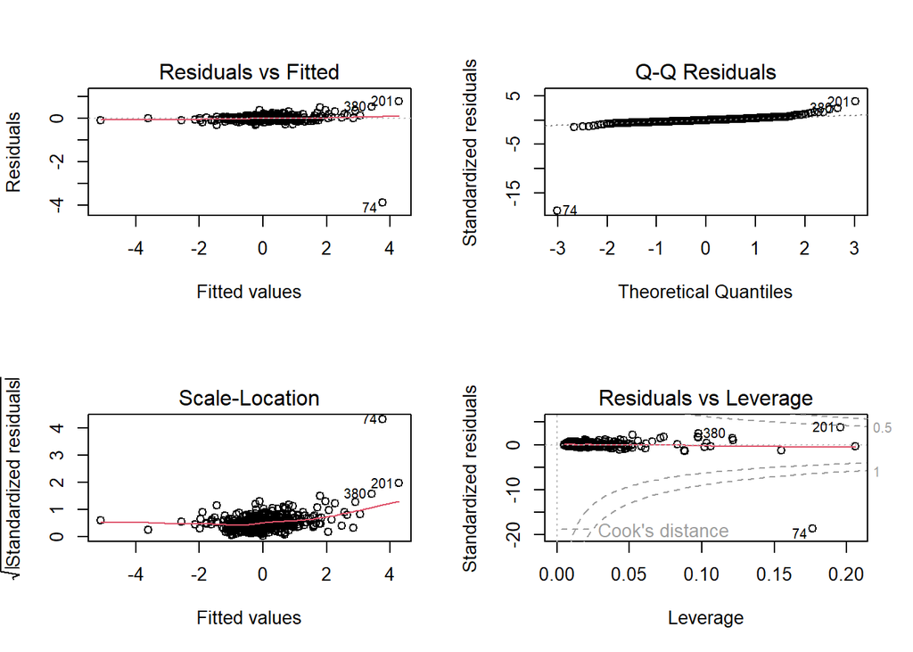

```r
par(mfrow = c(2, 2))   # 2 rows, 2 columns
step.zn_mod_plots <- plot(step.zn_mod)
```

```r
step.zn_mod_plots
```

Partial regression plots of log BLM parameters

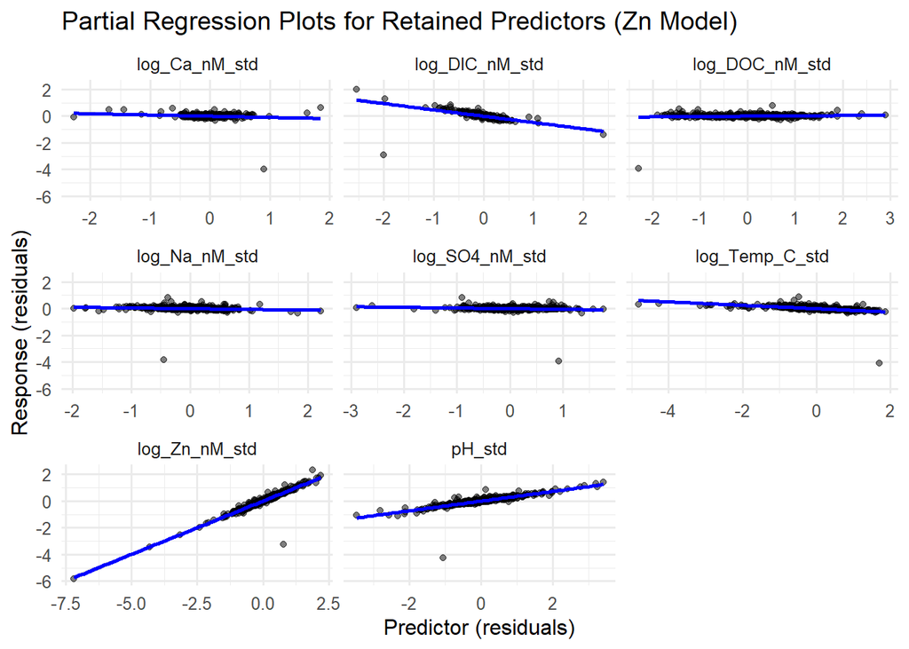

```r
library(dplyr)
library(ggplot2)
library(broom)

# 1. Extract retained predictors from stepwise model
retained_vars <- names(coef(step.zn_mod))[-1]  # drop intercept

# 2. Function to get partial residuals for each predictor
get_partial_df <- function(model, data, var) {
  # Construct model formula terms
  all_terms <- attr(terms(model), "term.labels")
  other_terms <- setdiff(all_terms, var)

  # Get residuals of Y on all predictors except the variable of interest
  y_formula <- reformulate(other_terms, response = all.vars(formula(model))[1])
  y_resid <- resid(lm(y_formula, data = data))

  # Get residuals of X_var on all other predictors
  x_formula <- reformulate(other_terms, response = var)
  x_resid <- resid(lm(x_formula, data = data))

  df <- data.frame(
    predictor = x_resid,
    response = y_resid,
    variable = var
  )
  return(df)
}

# 3. Build combined dataset for all retained predictors
partial_df <- do.call(rbind, lapply(retained_vars, get_partial_df,
                                    model = step.zn_mod, data = dat))

# 4. Plot partial regression slopes
step.zn_mod_partial_slopes <-
  ggplot(partial_df, aes(x = predictor, y = response)) +
  geom_point(alpha = 0.5) +
  geom_smooth(method = "lm", se = TRUE, color = "blue") + #95% CI
  facet_wrap(~ variable, scales = "free_x") +
  labs(
    x = "Predictor (residuals)",
    y = "Response (residuals)",
    title = "Partial Regression Plots for Retained Predictors (Zn Model)"
  ) +
  theme_minimal(base_size = 12)

step.zn_mod_partial_slopes
```

Create a summary table

```r
# 1. Create a data frame with raw beta coefficients (partial slopes)
summary_mlr_zn <- as.data.frame(summary(step.zn_mod)$coefficients)

# 2. Extract term names
summary_mlr_zn$Term <- rownames(summary_mlr_zn)

# 3. Reorder columns to put Term first
summary_mlr_zn <- summary_mlr_zn[, c("Term", setdiff(names(summary_mlr_zn), "Term"))]

# 4. Add model label
summary_mlr_zn$Model <- "Zinc"

# 5. Convert VIF values to data.frame for merging
vif_zn <- data.frame(
  Term = names(vif_coeff.zn),
  VIF = as.numeric(vif_coeff.zn),
  row.names = NULL
)

# 6. Merge the result with vif_zn
summary_zn <- merge(summary_mlr_zn, vif_zn, by = "Term", all.x = TRUE)

# 7. Add model statistics
zn_mod_summary <- summary(step.zn_mod)

rse <- zn_mod_summary$sigma
r2 <- zn_mod_summary$r.squared
adj_r2 <- zn_mod_summary$adj.r.squared
fstat <- zn_mod_summary$fstatistic[1]
fnum <- zn_mod_summary$fstatistic[2]
fden <- zn_mod_summary$fstatistic[3]
pval <- pf(fstat, fnum, fden, lower.tail = FALSE)

# 8. Create data frame with model statistics matching the structure of summary_zn
model_stats <- data.frame(
  Term = c("Residual standard error", "Multiple R-squared", "Adjusted R-squared", "F-statistic", "p-value"),
  Estimate = c(rse, r2, adj_r2, fstat, pval),
  `Std. Error` = NA,
  `t value` = NA,
  `Pr(>|t|)` = NA,
  Model = "Zinc",
  VIF = NA,
  stringsAsFactors = FALSE
)

# 9. Check and fix column name mismatches before combining

# 10. Scale both sets of column names
names(summary_zn) <- c(
  "Term", "Estimate", "Std. Error", "t value", "Pr(>|t|)", "Model", "VIF")
names(model_stats) <- c("Term", "Estimate", "Std. Error", "t value", "Pr(>|t|)", "Model", "VIF")

# 10. Combine coefficients and model stats
summary_zn_final <- rbind(summary_zn, model_stats)

# View
print(summary_zn_final)
```

```
##                       Term       Estimate Std. Error       t value
## 1              (Intercept)  -3.511047e-15 0.01162696 -3.019747e-13
## 2            log_Ca_nM_std  -9.157433e-02 0.03528485 -2.595287e+00
## 3           log_DIC_nM_std  -4.729238e-01 0.03224937 -1.466459e+01
## 4           log_DOC_nM_std   2.610669e-02 0.01410708  1.850609e+00
## 5            log_Na_nM_std  -5.400415e-02 0.02273727 -2.375138e+00
## 6           log_SO4_nM_std  -4.917535e-02 0.02108633 -2.332096e+00
## 7           log_Temp_C_std  -1.268450e-01 0.01253157 -1.012204e+01
## 8            log_Zn_nM_std   7.985383e-01 0.01395547  5.722044e+01
## 9                   pH_std   3.632103e-01 0.01310556  2.771422e+01
## 10 Residual standard error   2.284334e-01         NA            NA
## 11      Multiple R-squared   9.489025e-01         NA            NA
## 12      Adjusted R-squared   9.478182e-01         NA            NA
## 13             F-statistic   8.751309e+02         NA            NA
## 14                 p-value  3.364670e-238         NA            NA
##         Pr(>|t|) Model      VIF
## 1   1.000000e+00  Zinc       NA
## 2   9.820223e-03  Zinc 9.185821
## 3   7.623683e-39  Zinc 7.673330
## 4   6.500788e-02  Zinc 1.468303
## 5   1.804188e-02  Zinc 3.814328
## 6   2.022152e-02  Zinc 3.280525
## 7   1.835440e-21  Zinc 1.158650
## 8  5.737596e-188  Zinc 1.436913
## 9   5.617798e-93  Zinc 1.267221
## 10            NA  Zinc       NA
## 11            NA  Zinc       NA
## 12            NA  Zinc       NA
## 13            NA  Zinc       NA
## 14            NA  Zinc       NA
```

Export to excel

```r
library(openxlsx)

# Load the existing workbook
wb <- loadWorkbook("Statistical_analyses_all_sites.xlsx")

# Create sheet if it does NOT exist
if(!"Zn MLR" %in% names(wb)) {
  addWorksheet(wb, "Zn MLR")
}

# Write your new table
writeData(wb, "Zn MLR", summary_zn_final)

# Save the workbook (overwrite)
saveWorkbook(wb, "Statistical_analyses_all_sites.xlsx", overwrite = TRUE)
```

### b. Copper

```r
library(MASS)
library(car)

# Build a long model considering all predictors
cu_mod <- lm(log_TBL_Cu_nmol_g_std ~ log_Temp_C_std + pH_std + log_DOC_nM_std +
               log_Ca_nM_std + log_Mg_nM_std + log_Na_nM_std + log_K_nM_std +
               log_DIC_nM_std + log_SO4_nM_std + log_Cu_nM_std, data = dat)

# Step-wise selection of the most parsimonious model using AIC
step.cu_mod <- stepAIC(cu_mod, direction = "both", trace = FALSE)

# Summary of selected model
summary(step.cu_mod)
```

```
##
## Call:
## lm(formula = log_TBL_Cu_nmol_g_std ~ log_Temp_C_std + pH_std +
##     log_DOC_nM_std + log_Ca_nM_std + log_Mg_nM_std + log_Na_nM_std +
##     log_SO4_nM_std + log_Cu_nM_std, data = dat)
##
## Residuals:
##      Min       1Q   Median       3Q      Max
## -0.55213 -0.03905 -0.00225  0.03979  0.95951
##
## Coefficients:
##                  Estimate Std. Error t value Pr(>|t|)
## (Intercept)     5.687e-16  5.576e-03   0.000  1.00000
## log_Temp_C_std -5.254e-02  6.064e-03  -8.664  < 2e-16 ***
## pH_std         -5.528e-01  6.474e-03 -85.395  < 2e-16 ***
## log_DOC_nM_std -6.830e-01  8.421e-03 -81.098  < 2e-16 ***
## log_Ca_nM_std  -3.003e-02  1.024e-02  -2.932  0.00357 **
## log_Mg_nM_std  -2.576e-02  1.079e-02  -2.386  0.01753 *
## log_Na_nM_std  -5.668e-02  1.022e-02  -5.543 5.60e-08 ***
## log_SO4_nM_std  4.584e-02  1.049e-02   4.370 1.61e-05 ***
## log_Cu_nM_std   1.356e+00  8.829e-03 153.567  < 2e-16 ***
## ---
## Signif. codes:  0 '***' 0.001 '**' 0.01 '*' 0.05 '.' 0.1 ' ' 1
##
## Residual standard error: 0.1096 on 377 degrees of freedom
## Multiple R-squared:  0.9882, Adjusted R-squared:  0.988
## F-statistic:  3962 on 8 and 377 DF,  p-value: < 2.2e-16
```

Variance inflation factors

```r
vif_coeff.cu <- vif(step.cu_mod)
vif_coeff.cu
```

```
## log_Temp_C_std         pH_std log_DOC_nM_std  log_Ca_nM_std  log_Mg_nM_std
##       1.179298       1.344222       2.274707       3.363584       3.737250
##  log_Na_nM_std log_SO4_nM_std  log_Cu_nM_std
##       3.353259       3.529427       2.500012
```

Diagnostic plots

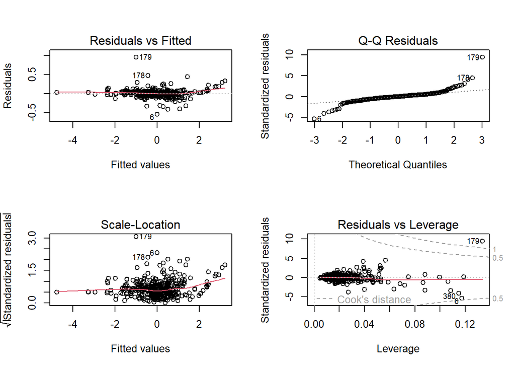

```r
par(mfrow = c(2, 2))
step.cu_mod_plots <- plot(step.cu_mod)
```

```r
step.cu_mod_plots
```

Partial regression plots

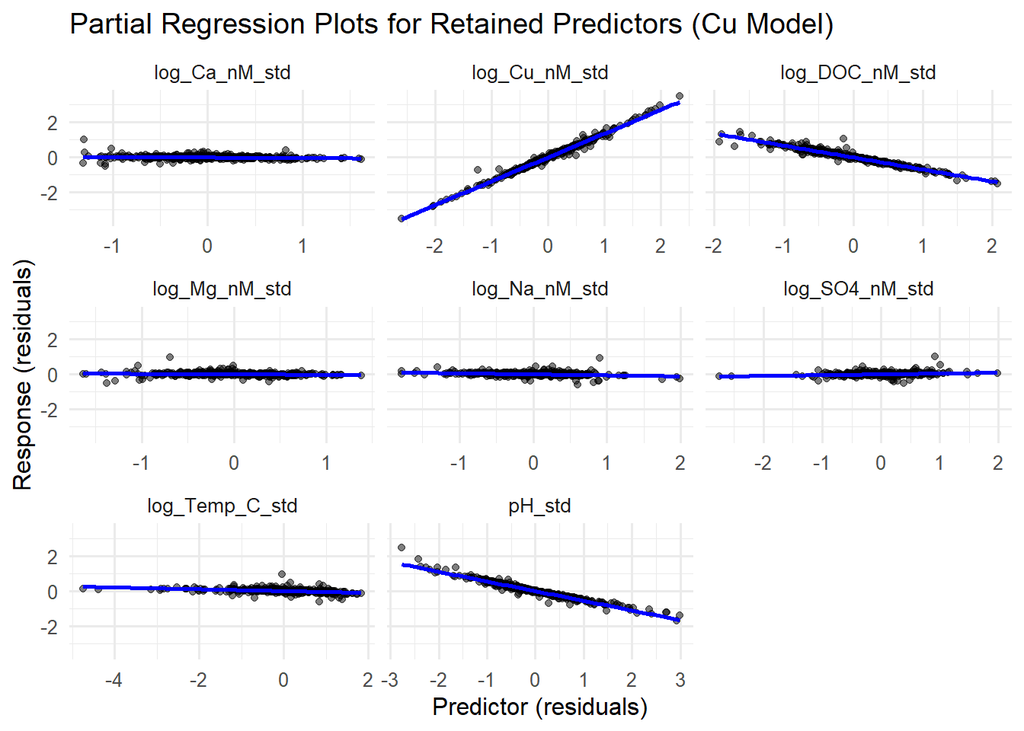

```r
library(ggplot2)
library(broom)
library(dplyr)

# 1. Extract retained predictors from stepwise model
retained_vars <- names(coef(step.cu_mod))[-1]  # drop intercept

# 2. Function to get partial residuals for each predictor
get_partial_df <- function(model, data, var) {
  # Construct model formula terms
  all_terms <- attr(terms(model), "term.labels")
  other_terms <- setdiff(all_terms, var)

  # Get residuals of Y on all predictors except the variable of interest
  y_formula <- reformulate(other_terms, response = all.vars(formula(model))[1])
  y_resid <- resid(lm(y_formula, data = data))

  # Get residuals of X_var on all other predictors
  x_formula <- reformulate(other_terms, response = var)
  x_resid <- resid(lm(x_formula, data = data))

  df <- data.frame(
    predictor = x_resid,
    response = y_resid,
    variable = var
  )
  return(df)
}

# 3. Build combined dataset for all retained predictors
partial_df <- do.call(rbind, lapply(retained_vars, get_partial_df,
                                    model = step.cu_mod, data = dat))

# 4. Plot partial regression slopes
step.cu_mod_partial_slopes <-
  ggplot(partial_df, aes(x = predictor, y = response)) +
  geom_point(alpha = 0.5) +
  geom_smooth(method = "lm", se = TRUE, color = "blue") + #95% CI
  facet_wrap(~ variable, scales = "free_x") +
  labs(
    x = "Predictor (residuals)",
    y = "Response (residuals)",
    title = "Partial Regression Plots for Retained Predictors (Cu Model)"
  ) +
  theme_minimal(base_size = 12)

step.cu_mod_partial_slopes
```

Summary table & export to excel

```r
# 1. Create a data frame with raw beta coefficients (partial slopes)
summary_mlr_cu <- as.data.frame(summary(step.cu_mod)$coefficients)

# 2. Extract term names
summary_mlr_cu$Term <- rownames(summary_mlr_cu)

# 3. Reorder columns to put Term first
summary_mlr_cu <- summary_mlr_cu[, c("Term", setdiff(names(summary_mlr_cu), "Term"))]

# 4. Add model label
summary_mlr_cu$Model <- "Copper"

# 5. Convert VIF values to data.frame for merging
vif_cu <- data.frame(
  Term = names(vif_coeff.cu),
  VIF = as.numeric(vif_coeff.cu),
  row.names = NULL
)

# 6. Merge the result with vif_cu
summary_cu <- merge(summary_mlr_cu, vif_cu, by = "Term", all.x = TRUE)

# 7. Add model statistics
cu_mod_summary <- summary(step.cu_mod)

rse <- cu_mod_summary$sigma
r2 <- cu_mod_summary$r.squared
adj_r2 <- cu_mod_summary$adj.r.squared
fstat <- cu_mod_summary$fstatistic[1]
fnum <- cu_mod_summary$fstatistic[2]
fden <- cu_mod_summary$fstatistic[3]
pval <- pf(fstat, fnum, fden, lower.tail = FALSE)

# 8. Create data frame with model statistics matching the structure of summary_cu
model_stats <- data.frame(
  Term = c("Residual standard error", "Multiple R-squared", "Adjusted R-squared", "F-statistic", "p-value"),
  Estimate = c(rse, r2, adj_r2, fstat, pval),
  `Std. Error` = NA,
  `t value` = NA,
  `Pr(>|t|)` = NA,
  Model = "Copper",
  VIF = NA,
  stringsAsFactors = FALSE
)

# 9. Check and fix column name mismatches before combining

# Scale both sets of column names
names(summary_cu) <- c("Term", "Estimate", "Std. Error", "t value", "Pr(>|t|)", "Model", "VIF")
names(model_stats) <- c("Term", "Estimate", "Std. Error", "t value", "Pr(>|t|)", "Model", "VIF")

# 10. Combine coefficients and model stats
summary_cu_final <- rbind(summary_cu, model_stats)

# View
print(summary_cu_final)
```

```
##                       Term      Estimate  Std. Error       t value
## 1              (Intercept)  5.687486e-16 0.005576473  1.019907e-13
## 2            log_Ca_nM_std -3.002552e-02 0.010240568 -2.932017e+00
## 3            log_Cu_nM_std  1.355788e+00 0.008828643  1.535670e+02
## 4           log_DOC_nM_std -6.829644e-01 0.008421426 -8.109844e+01
## 5            log_Mg_nM_std -2.575507e-02 0.010794411 -2.385963e+00
## 6            log_Na_nM_std -5.667663e-02 0.010224838 -5.543035e+00
## 7           log_SO4_nM_std  4.583694e-02 0.010489989  4.369589e+00
## 8           log_Temp_C_std -5.253836e-02 0.006063658 -8.664466e+00
## 9                   pH_std -5.528322e-01 0.006473788 -8.539547e+01
## 10 Residual standard error  1.095603e-01          NA            NA
## 11      Multiple R-squared  9.882460e-01          NA            NA
## 12      Adjusted R-squared  9.879965e-01          NA            NA
## 13             F-statistic  3.962135e+03          NA            NA
## 14                 p-value  0.000000e+00          NA            NA
##         Pr(>|t|)  Model      VIF
## 1   1.000000e+00 Copper       NA
## 2   3.573138e-03 Copper 3.363584
## 3   0.000000e+00 Copper 2.500012
## 4  1.011904e-240 Copper 2.274707
## 5   1.752732e-02 Copper 3.737250
## 6   5.596217e-08 Copper 3.353259
## 7   1.611397e-05 Copper 3.529427
## 8   1.353016e-16 Copper 1.179298
## 9  9.712489e-249 Copper 1.344222
## 10            NA Copper       NA
## 11            NA Copper       NA
## 12            NA Copper       NA
## 13            NA Copper       NA
## 14            NA Copper       NA
```

Export to excel

```r
library(openxlsx)

# Load the existing workbook
wb <- loadWorkbook("Statistical_analyses_all_sites.xlsx")

# Create sheet if it does NOT exist
if(!"Cu MLR" %in% names(wb)) {
  addWorksheet(wb, "Cu MLR")
}

# Write your new table
writeData(wb, "Cu MLR", summary_cu_final)

# Save the workbook (overwrite)
saveWorkbook(wb, "Statistical_analyses_all_sites.xlsx", overwrite = TRUE)
```

## 3. Outlier Detection

### i. Zinc Bioavailability

```r
# 1. Get model diagnostics
model_diag_zn <- influence.measures(step.zn_mod)

# 2. Extract indices of influential points flagged by diagnostics
infl_points_zn <- which(apply(model_diag_zn$is.inf, 1, any))

# 3. Create a dataframe with their info
flagged_obs_zn <- data.frame(
  Sample_ID = dat$Sample_ID[infl_points_zn],
  Fitted = fitted(step.zn_mod)[infl_points_zn],
  Residual = residuals(step.zn_mod)[infl_points_zn],
  Std_Residual = rstandard(step.zn_mod)[infl_points_zn],
  Leverage = hatvalues(step.zn_mod)[infl_points_zn],
  Cooks_D = cooks.distance(step.zn_mod)[infl_points_zn])

# View flagged observations
flagged_obs_zn
```

|  | Sample_ID | Fitted | Residual | Std_Residual | Leverage | Cooks_D |
| --- | --- | --- | --- | --- | --- | --- |
| 2 | WaDE_63 | -0.10629147 | 0.369279850 | 1.70124260 | 0.09705891 | 3.456734e-02 |
| 3 | WaDE_64 | 0.93608321 | -0.271555391 | -1.29310634 | 0.15485919 | 3.404348e-02 |
| 4 | WaDE_65 | 1.75565740 | -0.097672812 | -0.45123533 | 0.10211260 | 2.572890e-03 |
| 6 | WaDE_67 | 2.27126381 | 0.322067741 | 1.50386871 | 0.12106795 | 3.461395e-02 |
| 7 | WaDE_68 | -5.11169576 | -0.072355924 | -0.35547183 | 0.20600363 | 3.642707e-03 |
| 9 | WaDE_70 | -2.12795535 | -0.043191321 | -0.19413133 | 0.05140161 | 2.269045e-04 |
| 34 | WaDE_127 | -3.61515617 | 0.013472438 | 0.06159929 | 0.08331166 | 3.831713e-05 |
| 43 | WaDE_136 | -0.36455319 | 0.009144615 | 0.04111302 | 0.05190303 | 1.028150e-05 |
| 74 | WaDE_187 | 3.75573910 | -3.874307741 | -18.68894397 | 0.17643212 | 8.313909e+00 |
| 75 | WaDE_188 | 1.79929185 | 0.495232604 | 2.22662693 | 0.05200895 | 3.022221e-02 |

[output cut: 18 more lines]

Determine whether these flagged observations are clustered around a certain characteristic

```r
library(dplyr)

# 1. Add descriptive variables from dat to flagged observations (already done)
flagged_obs_zn <- flagged_obs_zn %>%
  left_join(dat %>%
              dplyr::select(Sample_ID, Site, Date, Typology), by = "Sample_ID")

### ---- By Typology ----
# 2a. Summarize how many flagged points per cluster
by_typ_zn <- flagged_obs_zn %>% count(Typology)

# 2b. Proportion of flagged by cluster
prop_typ_zn <- flagged_obs_zn %>%
  count(Typology) %>%
  mutate(prop_flagged = n / sum(n))

# 2c. Overall proportions in dataset
overall_typ_zn <- dat %>%
  count(Typology) %>%
  mutate(prop_overall = n / sum(n))

# 2d. Compare flagged vs overall
compare_typ_zn <- left_join(prop_typ_zn, overall_typ_zn, by = "Typology")


### ---- By Site ----
# 3a. Summarize flagged points per site
by_site_zn <- flagged_obs_zn %>% count(Site)

# 3b. Proportion flagged per site
prop_site_zn <- flagged_obs_zn %>%
  count(Site) %>%
  mutate(prop_flagged = n / sum(n))

# 3c. Overall proportions in dataset
overall_site_zn <- dat %>%
  count(Site) %>%
  mutate(prop_overall = n / sum(n))

# 3d. Compare flagged vs overall
compare_site_zn <- left_join(prop_site_zn, overall_site_zn, by = "Site")


### ---- By Date ----
# 4a. Summarize flagged points per date
by_date_zn <- flagged_obs_zn %>% count(Date)

# 4b. Proportion flagged per date
prop_date_zn <- flagged_obs_zn %>%
  count(Date) %>%
  mutate(prop_flagged = n / sum(n))

# 4c. Overall proportions in dataset
overall_date_zn <- dat %>%
  count(Date) %>%
  mutate(prop_overall = n / sum(n))

# 4d. Compare flagged vs overall
compare_date_zn <- left_join(prop_date_zn, overall_date_zn, by = "Date")

# 5. Combine plots
library(dplyr)

compare_typ_zn2 <- compare_typ_zn %>%
  rename(Value = Typology)

compare_site_zn2 <- compare_site_zn %>%
  rename(Value = Site)

compare_date_zn2 <- compare_date_zn %>%
  rename(Value = Date) %>%
  mutate(Value = as.character(Value))   # ✅ convert date to character

# Now combine all tables
combined_zn <- bind_rows(compare_typ_zn2, compare_site_zn2, compare_date_zn2)

# Check result
combined_zn
```

| Value | n.x | prop_flagged | n.y | prop_overall |
| --- | --- | --- | --- | --- |
| Developed Tributaries | 2 | 0.07142857 | 184 | 0.476683938 |
| Main Stem | 4 | 0.14285714 | 106 | 0.274611399 |
| Pooled Water | 7 | 0.25000000 | 30 | 0.077720207 |
| Tributaries | 15 | 0.53571429 | 66 | 0.170984456 |
| BSL4.2 | 1 | 0.03571429 | 4 | 0.010362694 |
| BSL4.3 | 1 | 0.03571429 | 4 | 0.010362694 |
| BSL6 | 1 | 0.03571429 | 1 | 0.002590674 |
| EFK13.8 | 1 | 0.03571429 | 11 | 0.028497409 |
| EFK20 | 1 | 0.03571429 | 10 | 0.025906736 |
| EFK23.5 | 2 | 0.07142857 | 11 | 0.028497409 |

[output cut: 18 more lines]

Export to excel

```r
library(openxlsx)

# Load the existing workbook
wb <- loadWorkbook("Statistical_analyses_all_sites.xlsx")

# Create sheet if it does NOT exist
if(!"Zn outliers" %in% names(wb)) {
  addWorksheet(wb, "Zn outliers")
}

# Write your new table
writeData(wb, "Zn outliers", combined_zn)

# Save the workbook (overwrite)
saveWorkbook(wb, "Statistical_analyses_all_sites.xlsx", overwrite = TRUE)
```

### ii. Copper Bioavailability

```r
# 1. Get model diagnostics
model_diag_cu <- influence.measures(step.cu_mod)

# 2. Extract indices of influential points flagged by diagnostics
infl_points_cu <- which(apply(model_diag_cu$is.inf, 1, any))

# 3. Create a dataframe with their info
flagged_obs_cu <- data.frame(
  Sample_ID = dat$Sample_ID[infl_points_cu],
  Fitted = fitted(step.zn_mod)[infl_points_cu],
  Residual = residuals(step.zn_mod)[infl_points_cu],
  Std_Residual = rstandard(step.zn_mod)[infl_points_cu],
  Leverage = hatvalues(step.zn_mod)[infl_points_cu],
  Cooks_D = cooks.distance(step.zn_mod)[infl_points_cu])

# View flagged observations
flagged_obs_cu
```

|  | Sample_ID | Fitted | Residual | Std_Residual | Leverage | Cooks_D |
| --- | --- | --- | --- | --- | --- | --- |
| 4 | WaDE_65 | 1.75565740 | -0.097672812 | -0.45123533 | 0.102112599 | 2.572890e-03 |
| 6 | WaDE_67 | 2.27126381 | 0.322067741 | 1.50386871 | 0.121067947 | 3.461395e-02 |
| 27 | WaDE_88 | 0.70929108 | -0.258377269 | -1.15644392 | 0.043378472 | 6.738151e-03 |
| 28 | WaDE_108 | 1.83924363 | 0.111929162 | 0.50055558 | 0.041785836 | 1.214028e-03 |
| 74 | WaDE_187 | 3.75573910 | -3.874307741 | -18.68894397 | 0.176432118 | 8.313909e+00 |
| 82 | WaDE_195 | -0.40716762 | -0.148610597 | -0.66824066 | 0.052204885 | 2.732876e-03 |
| 118 | WaDE_302 | 0.55181706 | -0.117539648 | -0.52511287 | 0.039838835 | 1.271233e-03 |
| 120 | WaDE_305 | -0.23010093 | -0.316269543 | -1.44982689 | 0.088066565 | 2.255473e-02 |
| 138 | WaDE_338 | -1.45672216 | -0.291368682 | -1.33532908 | 0.087590456 | 1.901959e-02 |
| 158 | WaDE_358 | 2.48931250 | 0.034153445 | 0.15293889 | 0.044316935 | 1.205172e-04 |

[output cut: 18 more lines]

Determine whether these flagged observations are clustered around a certain characteristic

```r
library(dplyr)

# 1. Add descriptive variables from dat to flagged observations (already done)
flagged_obs_cu <- flagged_obs_cu %>%
  left_join(dat %>% dplyr::select(Sample_ID, Site, Date, Typology), by = "Sample_ID")

### ---- By Typology ----
# 2a. Summarize how many flagged points per cluster
by_typ_cu <- flagged_obs_cu %>% count(Typology)

# 2b. Proportion of flagged by cluster
prop_typ_cu <- flagged_obs_cu %>%
  count(Typology) %>%
  mutate(prop_flagged = n / sum(n))

# 2c. Overall proportions in dataset
overall_typ_cu <- dat %>%
  count(Typology) %>%
  mutate(prop_overall = n / sum(n))

# 2d. Compare flagged vs overall
compare_typ_cu <- left_join(prop_typ_cu, overall_typ_cu, by = "Typology")


### ---- By Site ----
# 3a. Summarize flagged points per site
by_site_cu <- flagged_obs_cu %>% count(Site)

# 3b. Proportion flagged per site
prop_site_cu <- flagged_obs_cu %>%
  count(Site) %>%
  mutate(prop_flagged = n / sum(n))

# 3c. Overall proportions in dataset
overall_site_cu <- dat %>%
  count(Site) %>%
  mutate(prop_overall = n / sum(n))

# 3d. Compare flagged vs overall
compare_site_cu <- left_join(prop_site_cu, overall_site_cu, by = "Site")


### ---- By Date ----
# 4a. Summarize flagged points per date
by_date_cu <- flagged_obs_cu %>% count(Date)

# 4b. Proportion flagged per date
prop_date_cu <- flagged_obs_cu %>%
  count(Date) %>%
  mutate(prop_flagged = n / sum(n))

# 4c. Overall proportions in dataset
overall_date_cu <- dat %>%
  count(Date) %>%
  mutate(prop_overall = n / sum(n))

# 4d. Compare flagged vs overall
compare_date_cu <- left_join(prop_date_cu, overall_date_cu, by = "Date")

# 5. Combine into one table
library(dplyr)

compare_typ_cu2 <- compare_typ_cu %>%
  rename(Value = Typology)

compare_site_cu2 <- compare_site_cu %>%
  rename(Value = Site)

compare_date_cu2 <- compare_date_cu %>%
  rename(Value = Date) %>%
  mutate(Value = as.character(Value))   # convert date to character

# Now combine all tables
combined_cu <- bind_rows(compare_typ_cu2, compare_site_cu2, compare_date_cu2)

# Check result
combined_cu
```

| Value | n.x | prop_flagged | n.y | prop_overall |
| --- | --- | --- | --- | --- |
| Developed Tributaries | 5 | 0.17857143 | 184 | 0.476683938 |
| Main Stem | 7 | 0.25000000 | 106 | 0.274611399 |
| Pooled Water | 4 | 0.14285714 | 30 | 0.077720207 |
| Tributaries | 12 | 0.42857143 | 66 | 0.170984456 |
| BCK0.9 | 2 | 0.07142857 | 11 | 0.028497409 |
| BSL4.3 | 1 | 0.03571429 | 4 | 0.010362694 |
| BSL5.1 | 1 | 0.03571429 | 1 | 0.002590674 |
| EFK10.0 | 1 | 0.03571429 | 11 | 0.028497409 |
| EFK23.5 | 6 | 0.21428571 | 11 | 0.028497409 |
| Gum Hollow | 1 | 0.03571429 | 11 | 0.028497409 |

[output cut: 19 more lines]

Export to excel

```r
library(openxlsx)

# Load the existing workbook
wb <- loadWorkbook("Statistical_analyses_all_sites.xlsx")

# Create sheet if it does NOT exist
if(!"Cu outliers" %in% names(wb)) {
  addWorksheet(wb, "Cu outliers")
}

# Write your new table
writeData(wb, "Cu outliers", combined_cu)

# Save the workbook (overwrite)
saveWorkbook(wb, "Statistical_analyses_all_sites.xlsx", overwrite = TRUE)
```

Determine which samples were outliers for both Zn and Cu bioavailability

```r
common_outliers <- flagged_obs_zn %>%
  filter(Sample_ID %in% intersect(flagged_obs_zn$Sample_ID,
                                  flagged_obs_cu$Sample_ID))

common_outliers
```

| Sample_ID | Fitted | Residual | Std_Residual | Leverage | Cooks_D | Site | Date | Typology |
| --- | --- | --- | --- | --- | --- | --- | --- | --- |
| WaDE_65 | 1.7556574 | -0.09767281 | -0.4512353 | 0.10211260 | 0.002572890 | MTN2 | 2023-06-23 | Pooled Water |
| WaDE_67 | 2.2712638 | 0.32206774 | 1.5038687 | 0.12106795 | 0.034613954 | MCA3.2 | 2023-06-23 | Tributaries |
| WaDE_187 | 3.7557391 | -3.87430774 | -18.6889440 | 0.17643212 | 8.313908910 | MCA3.2 | 2023-08-15 | Tributaries |
| WaDE_305 | -0.2301009 | -0.31626954 | -1.4498269 | 0.08806656 | 0.022554734 | Pinhook Branch | 2023-12-19 | Developed Tributaries |
| WaDE_338 | -1.4567222 | -0.29136868 | -1.3353291 | 0.08759046 | 0.019019587 | NBO5 | 2023-12-19 | Pooled Water |
| WaDE_390 | 2.1662440 | 0.08207784 | 0.3794020 | 0.10312241 | 0.001838979 | NBO3 | 2024-02-22 | Tributaries |
| WaDE_397 | 0.8176510 | 0.30689457 | 1.3941168 | 0.07133134 | 0.016587290 | MCA3.3 | 2024-02-22 | Tributaries |
| WaDE_398 | 2.0698540 | 0.20350637 | 0.9505327 | 0.12157924 | 0.013894676 | MCA3.2 | 2024-02-22 | Tributaries |
| WaDE_420 | 1.9609185 | 0.37106125 | 1.6876429 | 0.07357388 | 0.025132255 | BSL4.3 | 2024-04-26 | Pooled Water |
| WaDE_422 | 4.2751815 | 0.79063208 | 3.8593534 | 0.19573260 | 0.402762744 | WBK2 | 2024-04-26 | Tributaries |

[output cut: 4 more lines]

Export to excel

```r
library(openxlsx)

# Load the existing workbook
wb <- loadWorkbook("Statistical_analyses_all_sites.xlsx")

# Create sheet if it does NOT exist
if(!"Common outliers" %in% names(wb)) {
  addWorksheet(wb, "Common outliers")
}

# Write your new table
writeData(wb, "Common outliers", common_outliers)

# Save the workbook (overwrite)
saveWorkbook(wb, "Statistical_analyses_all_sites.xlsx", overwrite = TRUE)
```

# Assessing Variables by Typology

First, we’ll import the the Bioavailability_Master_Spreadsheet_Clean_3.xlsx and name it dat:

```r
library(readxl)

dat <- read_excel("Bioavailability_Master_Spreadsheet_Clean_3.xlsx",
    sheet = "HA 10% Closed System")

head(dat)
```

| Typology | Sample_ID | Site | Date | Regime | Flow_state | Network | Relative_elevation_m | Dist_from_EFPC_km | Drainage_area_km2 | Developed_lulc | Type | Development | Distance_from_EFPC | Drainage_area | Orientation | Relative_elevation | pH | Temp_C | DOC_uM | Ca_uM | Mg_uM | Na_uM | K_uM | SO4_uM | Cl_uM | DIC_uM | Zn_uM | Cu_uM | Free_Zn_M | … |
| --- | --- | --- | --- | --- | --- | --- | --- | --- | --- | --- | --- | --- | --- | --- | --- | --- | --- | --- | --- | --- | --- | --- | --- | --- | --- | --- | --- | --- | --- | --- |
| Developed Tributaries | WaDE_62 | MTN1.1 | 2023-06-23 | NonPerennial | Flowing | MTN | 3.832 | 0.205 | 1.42 | 63.59 | Tributaries | Medium | <0.22 km | 0.94-11.81 km2 | North slope | 2.1-10.5 m | 7.21 | 16.5 | 75.83 | 1498 | 458.0 | 212 | 37.0 | 38.2 | 174 | 4352 | 0.0360 | 0.002600 | 1.522121e-13 | … |
| Main Stem | WaDE_63 | EFK13.8 | 2023-06-23 | Perennial | Flowing | EFK | 0.000 | 0.000 | 30.18 | 64.72 | Main Stem | Medium | Main stem | >11.81 km2 | Main stem | 0 m | 8.28 | 18.6 | 160.00 | 1338 | 333.0 | 295 | 54.0 | 139.0 | 172 | 955 | 0.0282 | 0.017400 | 4.059197e-13 | … |
| Tributaries | WaDE_64 | MTN4 | 2023-06-23 | Perennial | Flowing | MTN | 33.182 | 1.255 | 0.30 | 41.23 | Tributaries | Low | >0.99 km | <0.94 km2 | North slope | >10.5 m | 8.29 | 15.8 | 35.83 | 271 | 182.0 | 90 | 24.8 | 29.7 | 80 | 3223 | 0.1150 | 0.000488 | 5.126304e-13 | … |
| Pooled Water | WaDE_65 | MTN2 | 2023-06-23 | NonPerennial | Pooled | MTN | 12.872 | 0.673 | 0.74 | 54.43 | Tributaries | Medium | 0.22-0.99 km | <0.94 km2 | North slope | >10.5 m | 8.32 | 18.7 | 527.50 | 306 | 75.6 | 7 | 46.4 | 7.5 | 16 | 878 | 0.0707 | 0.035200 | 1.073178e-12 | … |
| Tributaries | WaDE_66 | MCA3.3 | 2023-06-23 | NonPerennial | Flowing | MCA | 30.455 | 0.995 | 0.16 | 58.52 | Tributaries | Medium | >0.99 km | <0.94 km2 | North slope | >10.5 m | 7.67 | 16.2 | 119.17 | 164 | 79.9 | 88 | 21.2 | 54.3 | 87 | 568 | 0.0316 | 0.000834 | 9.536256e-13 | … |
| Tributaries | WaDE_67 | MCA3.2 | 2023-06-23 | NonPerennial | Flowing | MCA | 25.535 | 0.939 | 0.22 | 56.61 | Tributaries | Medium | 0.22-0.99 km | <0.94 km2 | North slope | >10.5 m | 7.49 | 16.5 | 81.67 | 46 | 24.7 | 66 | 12.2 | 37.1 | 77 | 286 | 0.0819 | 0.003350 | 5.026322e-12 | … |

Set order of Typologies

```r
# Rearrange order
dat$Typology <- as.factor(dat$Typology)
dat$Typology <- factor(dat$Typology,
                          levels = c("Pooled Water",
                                     "Tributaries",
                                     "Developed Tributaries",
                                     "Main Stem"))

# Check
levels(dat$Typology)
```

```
## [1] "Pooled Water"          "Tributaries"           "Developed Tributaries"
## [4] "Main Stem"
```

## 1. Summary Statistics

Mean and standard error by typology

```r
library(dplyr)
library(tidyr)

# Standard error function
se <- function(x) {
  sd(x, na.rm = TRUE) / sqrt(sum(!is.na(x)))
}

# Mode function (returns the most frequent value)
get_mode <- function(x) {
  x <- x[!is.na(x)]
  if (length(x) == 0) return(NA)
  ux <- unique(x)
  ux[which.max(tabulate(match(x, ux)))]
}

summary_table <- dat %>%
  dplyr::select(Typology, where(is.numeric)) %>%  # keep Typology + numeric vars
  pivot_longer(
    cols = -Typology,
    names_to = "Variable",
    values_to = "Value"
  ) %>%
  group_by(Variable, Typology) %>%
  summarise(
    Mean     = mean(Value, na.rm = TRUE),
    Median   = median(Value, na.rm = TRUE),
    Mode     = get_mode(Value),
    Variance = var(Value, na.rm = TRUE),
    SE       = se(Value),
    .groups = "drop"
  )

summary_table
```

| Variable | Typology | Mean | Median | Mode | Variance | SE |
| --- | --- | --- | --- | --- | --- | --- |
| BL_Ca_mol_kg_Cu | Pooled Water | 2.962660e-10 | 3.157755e-10 | 2.027377e-10 | 4.418521e-21 | 1.213606e-11 |
| BL_Ca_mol_kg_Cu | Tributaries | 2.303552e-10 | 2.310952e-10 | 1.688945e-10 | 6.285928e-21 | 9.759166e-12 |
| BL_Ca_mol_kg_Cu | Developed Tributaries | 3.006840e-10 | 2.961775e-10 | 3.292134e-10 | 1.221110e-21 | 2.576134e-12 |
| BL_Ca_mol_kg_Cu | Main Stem | 2.843692e-10 | 2.857144e-10 | 3.305296e-10 | 3.719985e-22 | 1.873345e-12 |
| BL_Ca_mol_kg_Zn | Pooled Water | 7.942310e-13 | 7.645298e-13 | 6.419780e-13 | 4.056798e-26 | 3.677317e-14 |
| BL_Ca_mol_kg_Zn | Tributaries | 8.373355e-13 | 7.949363e-13 | 1.772717e-13 | 1.112382e-25 | 4.105396e-14 |
| BL_Ca_mol_kg_Zn | Developed Tributaries | 9.072697e-13 | 8.840148e-13 | 6.697392e-13 | 3.836646e-26 | 1.443999e-14 |
| BL_Ca_mol_kg_Zn | Main Stem | 9.028951e-13 | 8.738101e-13 | 2.603723e-12 | 7.141722e-26 | 2.595664e-14 |
| BL_Ca_nmol_g_Cu | Pooled Water | 2.962660e-04 | 3.157755e-04 | 2.027377e-04 | 4.418521e-09 | 1.213606e-05 |
| BL_Ca_nmol_g_Cu | Tributaries | 2.303552e-04 | 2.310952e-04 | 1.688945e-04 | 6.285928e-09 | 9.759166e-06 |

[output cut: 1694 more lines]

Export to excel

```r
library(openxlsx)

# ----------------------------------------------------------
# 1. File name
# ----------------------------------------------------------
file_path <- "Statistical_analyses_by_typology.xlsx"

# ----------------------------------------------------------
# 2. Load workbook if exists, otherwise create a new one
# ----------------------------------------------------------
if (file.exists(file_path)) {
  wb <- loadWorkbook(file_path)
} else {
  wb <- createWorkbook()
}

# ----------------------------------------------------------
# 3. Create sheet if it does NOT exist
# ----------------------------------------------------------
if (!"Summary Stats" %in% names(wb)) {
  addWorksheet(wb, "Summary Stats")
}

# ----------------------------------------------------------
# 4. Write data to the sheet
# ----------------------------------------------------------
writeData(wb, "Summary Stats", summary_table)

# ----------------------------------------------------------
# 5. Save workbook (overwrite = TRUE allows updating)
# ----------------------------------------------------------
saveWorkbook(wb, file_path, overwrite = TRUE)
```

## 2. Check of ANOVA Assumptions

To determine whether variables significantly differ by typology, we could use a parametric ANOVA which assumes variables are normally distributed and have homogeneity of variance by typology. We already determined that most variables were not normally distributed (**Preparing Variables** section), even after log-transforming them. Now we will assess homogeneity of variance by typology.

### a. Homogeneity of Variance

Using the Levene Test

```r
library(car)  # for leveneTest()
library(dplyr)

# Set alpha for homogeneity check
alpha <- 0.05

# Identify all numeric variables EXCEPT Typology
numeric_vars <- dat %>%
  dplyr::select(where(is.numeric)) %>%
  names()

# Initialize results dataframe
levene_results <- data.frame(
  Variable = character(),
  F_value = numeric(),
  p_value = numeric(),
  Homogeneous = logical(),
  stringsAsFactors = FALSE
)

# Loop over all numeric variables
for (var in numeric_vars) {

  # Run Levene's test
  test <- car::leveneTest(as.formula(paste(var, "~ Typology")), data = dat)

  # Extract F and p-values
  F_val <- test[1, "F value"]
  p_val <- test[1, "Pr(>F)"]

  # Determine homogeneity
  homogeneous <- p_val > alpha

  # Add results to dataframe
  levene_results <- rbind(
    levene_results,
    data.frame(
      Variable = var,
      F_value = F_val,
      p_value = p_val,
      Homogeneous = homogeneous
    )
  )
}

# View results
levene_results
```

| Variable | F_value | p_value | Homogeneous |
| --- | --- | --- | --- |
| Relative_elevation_m | 52.8990512 | 1.288843e-28 | FALSE |
| Dist_from_EFPC_km | 112.7938088 | 2.574421e-52 | FALSE |
| Drainage_area_km2 | 97.1940760 | 9.225210e-47 | FALSE |
| Developed_lulc | 7.7161323 | 5.124723e-05 | FALSE |
| pH | 0.9480345 | 4.174012e-01 | TRUE |
| Temp_C | 2.3557420 | 7.152296e-02 | TRUE |
| DOC_uM | 7.7482323 | 4.906109e-05 | FALSE |
| Ca_uM | 16.6667280 | 3.393401e-10 | FALSE |
| Mg_uM | 8.8937860 | 1.038025e-05 | FALSE |
| Na_uM | 28.2831093 | 1.548494e-16 | FALSE |

[output cut: 416 more lines]

Most variables do not have homogeneous variance.

Export results to excel

```r
library(openxlsx)

# Load the existing workbook
wb <- loadWorkbook("Statistical_analyses_by_typology.xlsx")

# Create sheet if it does NOT exist
if(!"Homog Var by Typology" %in% names(wb)) {
  addWorksheet(wb, "Homog Var by Typology")
}

# Write your new table
writeData(wb, "Homog Var by Typology", levene_results)

# Save the workbook (overwrite)
saveWorkbook(wb, "Statistical_analyses_by_typology.xlsx", overwrite = TRUE)
```

## 3. Kruskal Wallis Test

**Assumptions of the KW test** according to geeksforgeeks.org

1. *For ordinal, interval, or ratio data:* While most of our variables fail this assumption, we can make an exception while being aware of this.
2. *The samples are independent of each other and within each group:* Our variables meet this assumption.
3. *The distributions of the groups should have the same shape.*

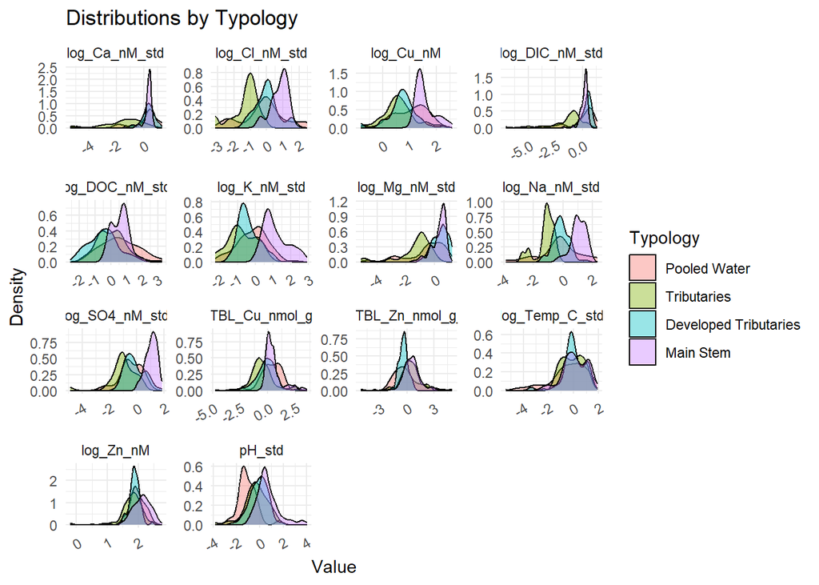

```r
library(dplyr)
library(tidyr)
library(ggplot2)

# Choose variables whose distributions you want to compare by Typology
vars_to_check <- c(
  "log_Zn_nM",
  "log_TBL_Zn_nmol_g_std",
  "log_Cu_nM",
  "log_TBL_Cu_nmol_g_std",
  "log_Temp_C_std",
  "pH_std",
  "log_DOC_nM_std",
  "log_DIC_nM_std",
  "log_Cl_nM_std",
  "log_Ca_nM_std",
  "log_Mg_nM_std",
  "log_SO4_nM_std",
  "log_Na_nM_std",
  "log_K_nM_std"
)

# Change to long format
dat_long <- dat %>%
  # Keep Typology and the variables you want to check
  dplyr::select(Typology, all_of(vars_to_check)) %>%

  # Turn columns into rows: Variable, Value
  pivot_longer(
    cols      = -Typology,
    names_to  = "Variable",
    values_to = "Value"
  )

# Density plots by Typology
ggplot(dat_long, aes(x = Value, fill = Typology)) +
  geom_density(alpha = 0.4) +   # alpha for transparent fill
  facet_wrap(~ Variable, scales = "free") +  # one panel per Variable
  labs(
    title = "Distributions by Typology",
    x = "Value",
    y = "Density"
  ) +
  theme_minimal() +
  theme(
    axis.text.x = element_text(angle = 30, hjust = 1)
  )
```

Generally, the distributions are similar by Typology for each Variable except for Ca, Cu, Zn, and DIC.

The KW test also can’t handle variables with missing values and no variance, we’ll check to see if any variables have these two conditions

```r
library(dplyr)

na_counts <- dat %>%
  dplyr::select(where(is.numeric)) %>%
  summarise(across(everything(), ~sum(is.na(.)))) %>%
  pivot_longer(everything(),
               names_to = "Variable",
               values_to = "NA_count") %>%
  filter(NA_count > 0)

na_counts
```

| Variable | NA_count |
| --- | --- |

No variables have missing values, now we’ll check for lack of variance

```r
no_variance <- dat %>%
  dplyr::select(where(is.numeric)) %>%
  summarise(across(everything(), ~dplyr::n_distinct(., na.rm = TRUE))) %>%
  pivot_longer(everything(),
               names_to = "Variable",
               values_to = "Distinct_values") %>%
  filter(Distinct_values <= 1)

no_variance
```

| Variable | Distinct_values |
| --- | --- |

If there are variables with no variance, it’s likely an error from running BLM.

Now we can perform the KW test

```r
library(tibble)
library(agricolae)
library(dplyr)

alpha <- 0.05

# 1. Get all numeric variables in dat
numeric_vars <- dat %>%
  dplyr::select(where(is.numeric)) %>%
  names()

# 2. Create an empty list to store rows
combined_list <- list()

# 3. Loop through each numeric variable
i <- 1
for (v in numeric_vars) {

  # Kruskal-Wallis test
  formula <- as.formula(paste(v, "~ Typology"))
  kw_test <- kruskal.test(formula, data = dat)

  chi_sq     <- kw_test$statistic
  df_val     <- kw_test$parameter
  p_val      <- kw_test$p.value
  significant <- p_val < alpha   # significant when p < 0.05

  # agricolae::kruskal to assign groups (letters)
  k_out <- agricolae::kruskal(
    y    = dat[[v]],
    trt  = dat$Typology,
    alpha = alpha,
    group = TRUE
  )

  # Create a data frame from the groups table
  groups_df <- k_out$groups %>%
    rownames_to_column("Typology")

  # Combine test results with group letters
  combined_list[[i]] <- groups_df %>%
    mutate(
      Variable   = v,
      Chi_sq     = as.numeric(chi_sq),
      df         = as.numeric(df_val),
      p_value    = as.numeric(p_val),
      Significant = significant
    )

  i <- i + 1
}

# 5. Bind everything together
combined_kruskal <- bind_rows(combined_list)

# View
combined_kruskal
```

| Typology | dat[[v]] | groups | Variable | Chi_sq | df | p_value | Significant |
| --- | --- | --- | --- | --- | --- | --- | --- |
| Pooled Water | 305.68333 | a | Relative_elevation_m | 268.164172 | 3 | 7.702665e-58 | TRUE |
| Tributaries | 295.84848 | a | Relative_elevation_m | 268.164172 | 3 | 7.702665e-58 | TRUE |
| Developed Tributaries | 219.14946 | b | Relative_elevation_m | 268.164172 | 3 | 7.702665e-58 | TRUE |
| Main Stem | 53.50000 | c | Relative_elevation_m | 268.164172 | 3 | 7.702665e-58 | TRUE |
| Pooled Water | 278.51667 | a | Dist_from_EFPC_km | 238.152777 | 3 | 2.387601e-51 | TRUE |
| Tributaries | 248.74242 | b | Dist_from_EFPC_km | 238.152777 | 3 | 2.387601e-51 | TRUE |
| Developed Tributaries | 240.47554 | b | Dist_from_EFPC_km | 238.152777 | 3 | 2.387601e-51 | TRUE |
| Main Stem | 53.50000 | c | Dist_from_EFPC_km | 238.152777 | 3 | 2.387601e-51 | TRUE |
| Main Stem | 304.02830 | a | Drainage_area_km2 | 168.620467 | 3 | 2.526266e-36 | TRUE |
| Developed Tributaries | 175.67120 | b | Drainage_area_km2 | 168.620467 | 3 | 2.526266e-36 | TRUE |

[output cut: 1694 more lines]

Export to excel

```r
library(openxlsx)

# Load the existing workbook
wb <- loadWorkbook("Statistical_analyses_by_typology.xlsx")

# Create sheet if it does NOT exist
if(!"K-W test by Typology" %in% names(wb)) {
  addWorksheet(wb, "K-W test by Typology")
}

# Write your new table
writeData(wb, "K-W test by Typology", combined_kruskal)

# Save the workbook (overwrite)
saveWorkbook(wb, "Statistical_analyses_by_typology.xlsx", overwrite = TRUE)
```

## 4. Boxplots by Typology

We first need to create an object with the pair-wise comparison letters

```r
# Create letters_df from combined_kruskal
letters_df <- combined_kruskal %>%
  dplyr::select(Variable, Typology, groups) %>%
  dplyr::distinct() %>%
  dplyr::rename(Letters = groups)
```

### a. BLM Predictors

Create a boxplots for each BLM predictor

```r
library(fBasics)
```

```r
library(tibble)
library(agricolae)
library(ggplot2)
library(dplyr)
Sys.setlocale("LC_CTYPE", "English_United States.UTF-8")
```

```
## [1] "English_United States.utf8"
```

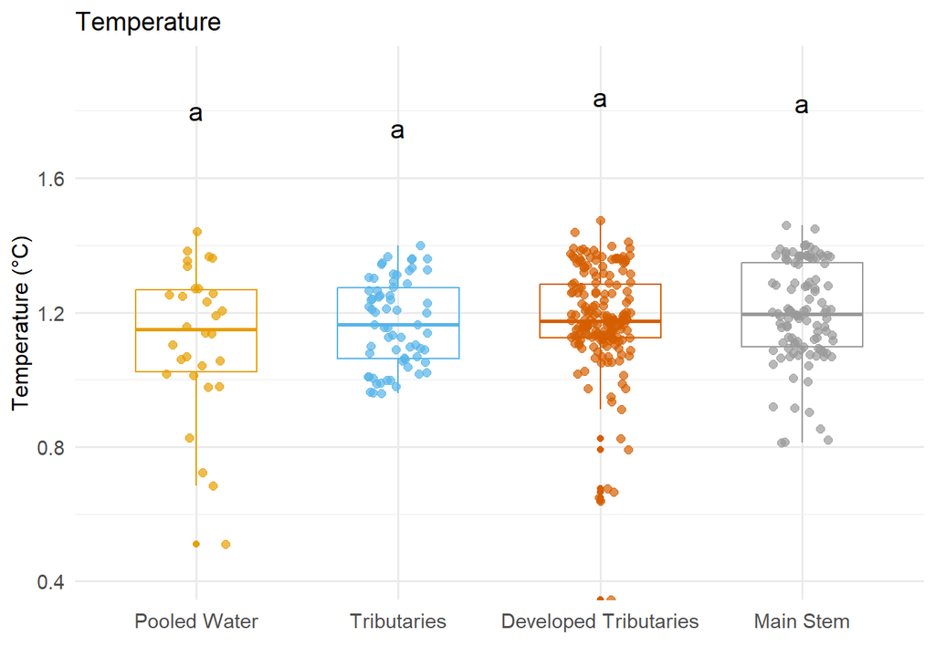

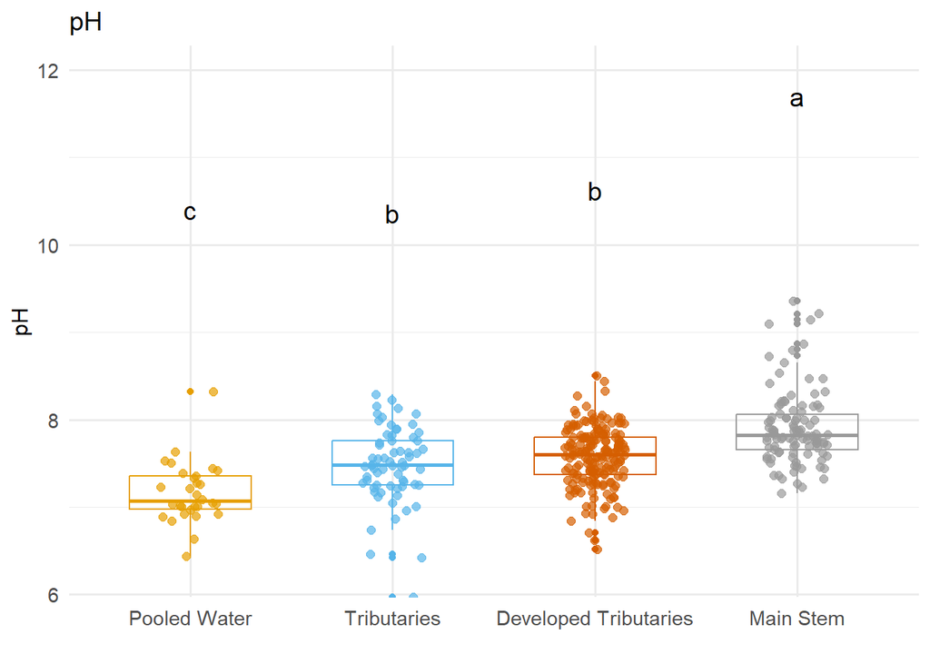

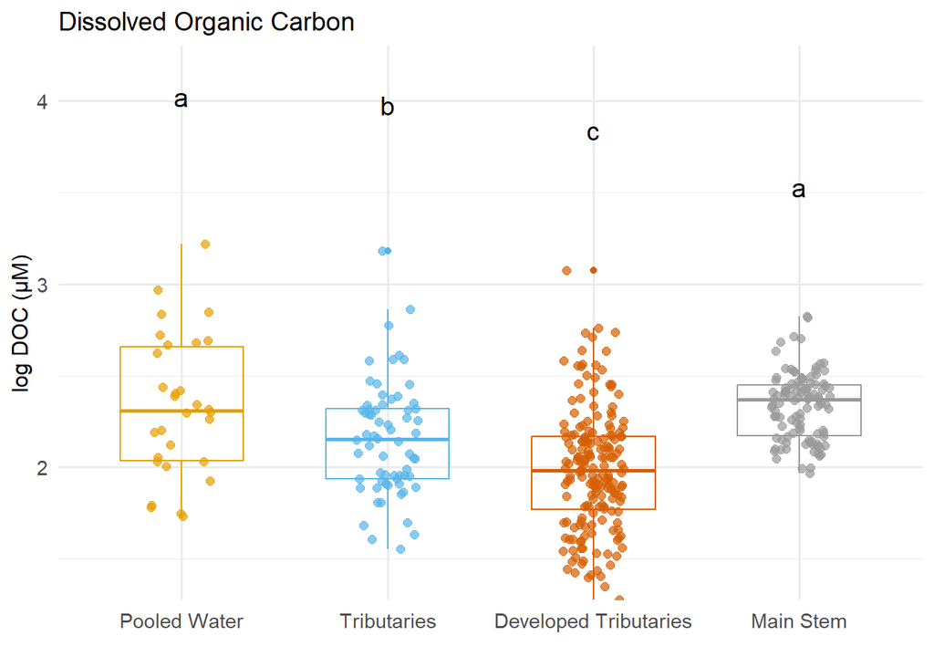

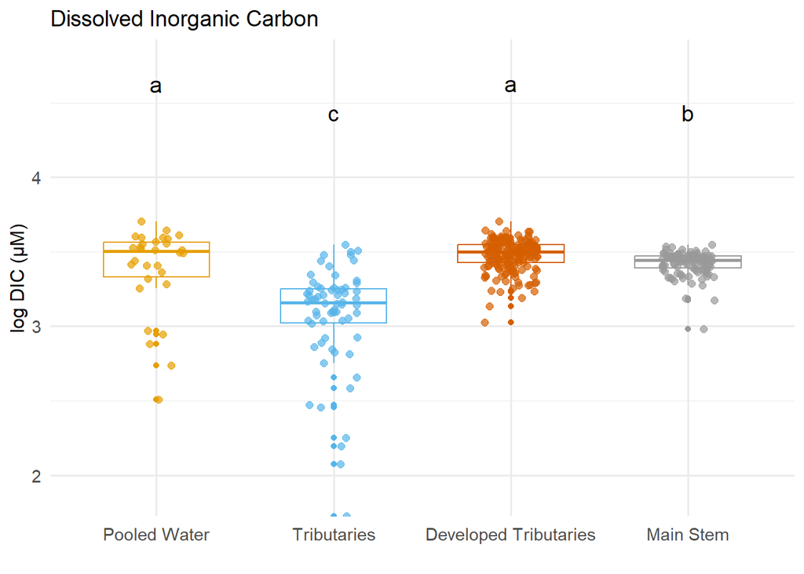

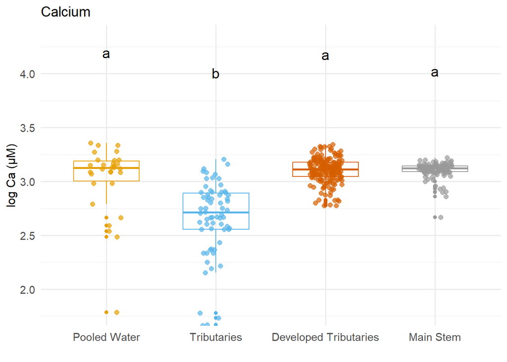

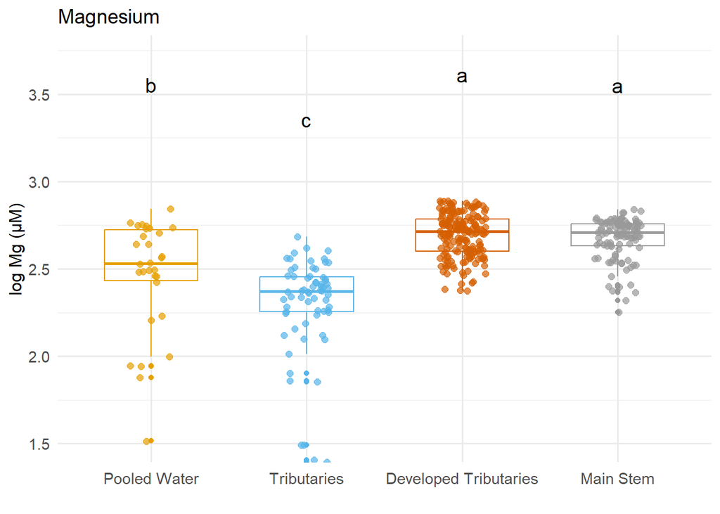

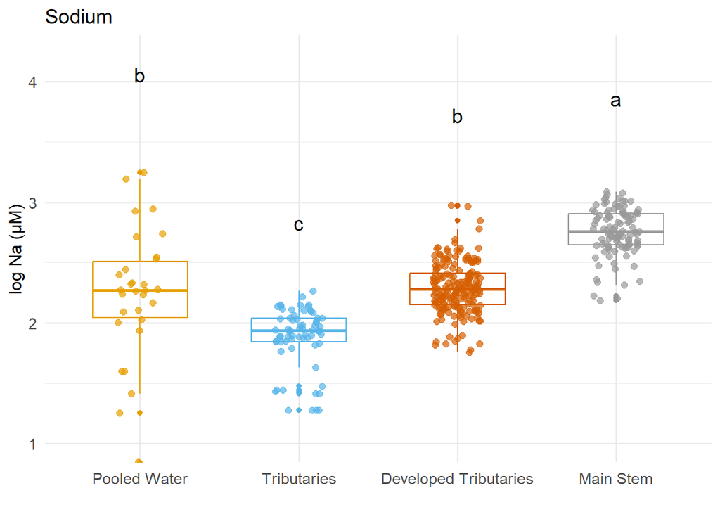

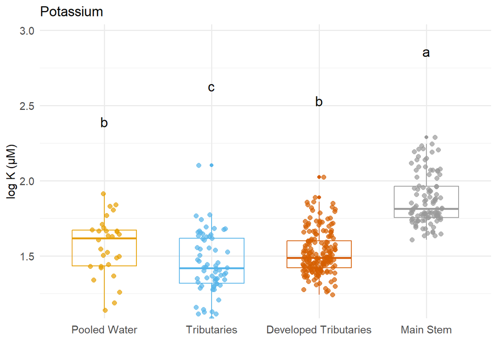

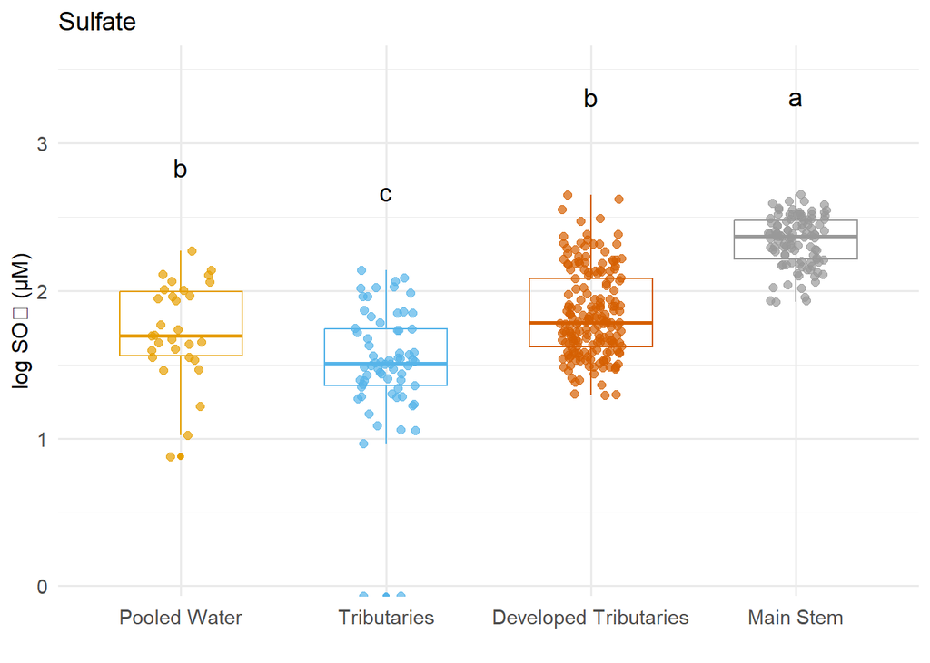

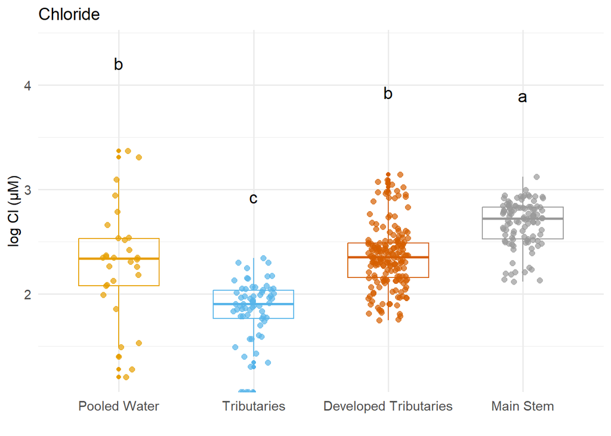

```r
# 1. Titles for each variable's plot (panel title)
title_lookup <- c(
  "log_Temp_C" = "Temperature",
  "pH"         = "pH",
  "log_DOC_uM" = "Dissolved Organic Carbon",
  "log_DIC_uM" = "Dissolved Inorganic Carbon",
  "log_Ca_uM"  = "Calcium",
  "log_Mg_uM"  = "Magnesium",
  "log_Na_uM"  = "Sodium",
  "log_K_uM"   = "Potassium",
  "log_SO4_uM" = "Sulfate",
  "log_Cl_uM"  = "Chloride"
)

# 2. Custom y-axis labels for each variable
y_label_lookup <- c(
  "log_Temp_C" = "Temperature (°C)",
  "pH"         = "pH",
  "log_DOC_uM" = "log DOC (µM)",
  "log_DIC_uM" = "log DIC (µM)",
  "log_Ca_uM"  = "log Ca (µM)",
  "log_Mg_uM"  = "log Mg (µM)",
  "log_Na_uM"  = "log Na (µM)",
  "log_K_uM"   = "log K (µM)",
  "log_SO4_uM" = "log SO₄ (µM)",
  "log_Cl_uM"  = "log Cl (µM)"
)

# 3. Colors for each Typology abbreviation
typology_colors <- c(
  "Pooled Water"        = "#E69F00",
  "Tributaries"         = "#56B4E9",
  "Developed Tributaries" = "#D55E00",
  "Main Stem"           = "#999999"
)

# 4. Create output folder (if it doesn't exist)
output_dir <- "Plots by Typology"
if (!dir.exists(output_dir)) dir.create(output_dir)

# 5. Loop through variables in title_lookup
for (var in names(title_lookup)) {

  # a) y-position for letters: e.g. 1.25 * max per Typology
  y_pos_df <- dat %>%
    group_by(Typology) %>%
    summarise(
      y_pos = max(.data[[var]], na.rm = TRUE) * 1.25,
      .groups = "drop"
    )

  # b) SUBSET your letters table for this variable
  #    letters_df must have columns: Variable, Typology, Letters
  letters_sub <- letters_df %>%
    filter(Variable == var) %>%
    dplyr::select(Typology, Letters)

  # c) JOIN letters with y positions
  letters_plot_df <- letters_sub %>%
    left_join(y_pos_df, by = "Typology")

  # d) Build ggplot
  p <- ggplot(dat, aes(
      x = Typology,
      y = .data[[var]],
      color = Typology
    )) +
    geom_boxplot(fill = NA, width = 0.6) +
    geom_jitter(
      width = 0.15,
      size = 2,
      alpha = 0.7
    ) +
    geom_text(
      data = letters_plot_df,
      aes(
        x = Typology,
        y = y_pos,
        label = Letters
      ),
      inherit.aes = FALSE,
      size = 5
    ) +
    scale_color_manual(values = typology_colors) +
    labs(
      title = title_lookup[[var]],
      y     = y_label_lookup[[var]],
      x     = ""
    ) +
    scale_y_continuous(expand = expansion(mult = c(0, 0.1))) +
    theme_minimal(base_size = 12) +
    theme(
      legend.position = "none",
      axis.text.x  = element_text(size = 11, angle = 0, vjust = 0.5),
      axis.title.x = element_text(size = 12),
      axis.text.y  = element_text(size = 11),
      axis.title.y = element_text(size = 12),
      plot.title   = element_text(size = 14)
    )

  print(p)
}
```

Save plot

```r
  ggsave(
    filename = file.path(output_dir, paste0(var, ".png")),
    plot     = p,
    width    = 5,
    height   = 4,
    dpi      = 300
  )
```

Boxplots of BLM predictors on a single pane - fix

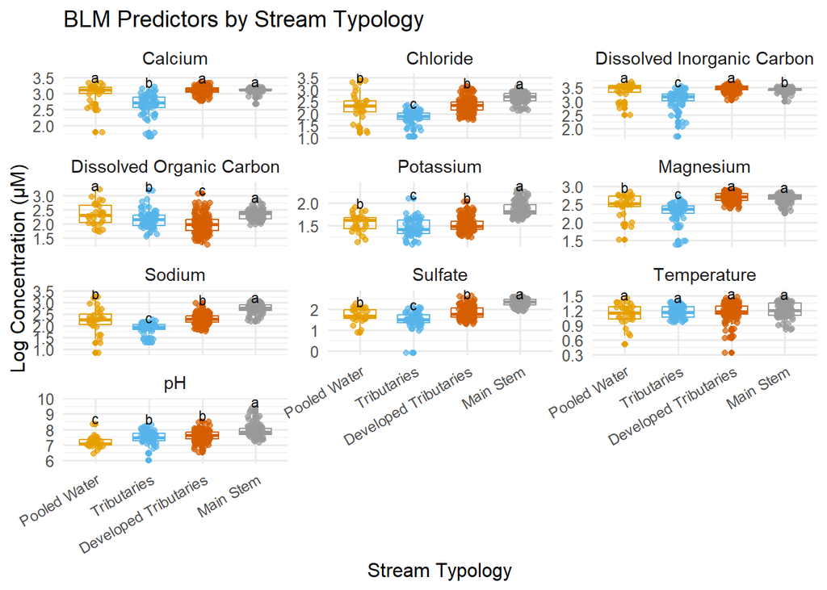

```r
library(dplyr)
library(tidyr)
library(ggplot2)

# ------------------------------------------------------------------
# 0. Typology colors (exactly as you specified)
# ------------------------------------------------------------------
typology_colors <- c(
  "Pooled Water"          = "#E69F00",
  "Tributaries"           = "#56B4E9",
  "Developed Tributaries" = "#D55E00",
  "Main Stem"             = "#999999"
)

# 1. Make sure output folder exists
output_dir <- "Plots by Typology"
if (!dir.exists(output_dir)) dir.create(output_dir)

# 2. Put data into long format: one row = 1 observation of 1 variable
dat_long <- dat %>%
  dplyr::select(Typology, all_of(names(title_lookup))) %>%
  pivot_longer(
    cols      = -Typology,
    names_to  = "Variable",
    values_to = "Value"
  ) %>%
  filter(!is.na(Value))

# 3. Prepare letters for all variables in one table ----

# 3a. Get max y per Variable x Typology from the long data
y_pos_df <- dat_long %>%
  group_by(Variable, Typology) %>%
  summarise(y_max = max(Value, na.rm = TRUE), .groups = "drop")

# 3b. Subset letters_df to only the variables you are plotting
#     letters_df must have: Variable, Typology, Letters
letters_long <- letters_df %>%
  filter(Variable %in% names(title_lookup)) %>%
  # join to get y_max for each Variable x Typology
  left_join(y_pos_df, by = c("Variable", "Typology")) %>%
  # position letters slightly above the max
  mutate(
    y_pos = y_max * 1.05
  )

# 4. Facet labels using title_lookup
facet_labels <- as_labeller(title_lookup)

# 5. Build one faceted plot
all_vars_panel <- ggplot(dat_long, aes(
    x     = Typology,
    y     = Value,
    color = Typology
  )) +
  # Boxplots
  geom_boxplot(fill = NA, width = 0.6) +

  # Jittered points
  geom_jitter(
    width = 0.15,
    size  = 1.5,
    alpha = 0.7
  ) +

  # Letters from Kruskal groups
  geom_text(
    data = letters_long,
    aes(
      x     = Typology,
      y     = y_pos,
      label = Letters
    ),
    inherit.aes = FALSE,
    size = 3
  ) +

  # Typology colors
  scale_color_manual(values = typology_colors) +

  # Facet by Variable, with nice titles
  facet_wrap(
    ~ Variable,
    scales  = "free_y",
    ncol    = 3,
    labeller = facet_labels
  ) +

  labs(
    title = "BLM Predictors by Stream Typology",
    x     = "Stream Typology",
    y     = "Log Concentration (µM)"
  ) +

  theme_minimal(base_size = 12) +
  theme(
    legend.position = "none",
    axis.text.x  = element_text(size = 9, angle = 30, hjust = 1),
    strip.text   = element_text(size = 11),
    plot.title   = element_text(size = 14)
  )

# 6. Show in RStudio
all_vars_panel
```

Save plot

```r
ggsave(
  filename = file.path(output_dir, "All_BLM_predictors_square.png"),
  plot     = all_vars_panel,
  width    = 9,
  height   = 9,
  dpi      = 300
)
```

### b. Trace Elements

Response variables (Zn and Cu species) - fix

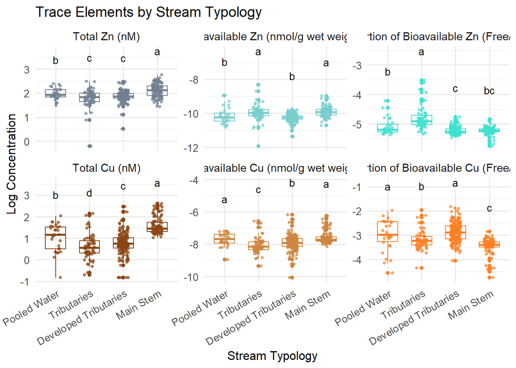

```r
library(dplyr)
library(tidyr)
library(ggplot2)

#-------------------------------------------------
# 1. Colors by response variable (your mapping)
#-------------------------------------------------
response_colors <- c(
  "Total Zn (nM)"                              = "slategray",
  "Bioavailable Zn (nmol/g wet weight)"        = "darkslategray3",
  "Proportion of Bioavailable Zn (Free/Total)" = "turquoise",
  "Total Cu (nM)"                              = "chocolate4",
  "Bioavailable Cu (nmol/g wet weight)"        = "peru",
  "Proportion of Bioavailable Cu (Free/Total)" = "chocolate1"
)

#-------------------------------------------------
# 2. Map variable names -> response labels
#-------------------------------------------------
response_lookup <- c(
  "log_Zn_nM"         = "Total Zn (nM)",
  "log_TBL_Zn_nmol_g" = "Bioavailable Zn (nmol/g wet weight)",
  "log_rel_prop_Zn"   = "Proportion of Bioavailable Zn (Free/Total)",
  "log_Cu_nM"         = "Total Cu (nM)",
  "log_TBL_Cu_nmol_g" = "Bioavailable Cu (nmol/g wet weight)",
  "log_rel_prop_Cu"   = "Proportion of Bioavailable Cu (Free/Total)"
)

vars_trace <- names(response_lookup)

#-------------------------------------------------
# 3. Custom multipliers for letter heights per plot
#    (names must match Response labels)
#-------------------------------------------------
letter_nudge <- c(
  "Total Zn (nM)"                              = 1,
  "Bioavailable Zn (nmol/g wet weight)"        = 2,
  "Proportion of Bioavailable Zn (Free/Total)" = 1,
  "Total Cu (nM)"                              = 1,
  "Bioavailable Cu (nmol/g wet weight)"        = 2,
  "Proportion of Bioavailable Cu (Free/Total)" = 1
)

#-------------------------------------------------
# 4. Long data for plotting (use Typology)
#-------------------------------------------------
dat_long_trace <- dat %>%
  dplyr::select(Typology, all_of(vars_trace)) %>%
  pivot_longer(
    cols      = -Typology,
    names_to  = "Variable",
    values_to = "Value"
  ) %>%
  filter(!is.na(Value)) %>%
  mutate(
    Response = response_lookup[Variable],
    Response = factor(Response, levels = names(response_colors))
  )

#-------------------------------------------------
# 5. Letters (from letters_df) for all 6 variables
#-------------------------------------------------

# 5a. Max y per Variable x Typology
y_pos_df <- dat_long_trace %>%
  group_by(Variable, Typology) %>%
  summarise(y_max = max(Value, na.rm = TRUE), .groups = "drop")

# 5b. Attach Response + y positions + nudges to letters_df
#     letters_df must have: Variable, Typology, Letters
letters_long_trace <- letters_df %>%
  filter(Variable %in% vars_trace) %>%
  mutate(
    Response = response_lookup[Variable],
    Response = factor(Response, levels = names(response_colors))
  ) %>%
  left_join(
    y_pos_df,
    by = c("Variable", "Typology")
  ) %>%
  mutate(
    # add different nudge per facet
    y_pos = y_max + letter_nudge[as.character(Response)]
  )

#-------------------------------------------------
# 6. One faceted trace element panel (x = Typology)
#-------------------------------------------------
bioavail_panel <- ggplot(dat_long_trace, aes(
    x     = Typology,
    y     = Value,
    color = Response
  )) +
  # Boxplots
  geom_boxplot(fill = NA, width = 0.6) +

  # Jittered points
  geom_jitter(
    width = 0.15,
    size  = 1,
    alpha = 0.7
  ) +

  # Letters from Kruskal groups
  geom_text(
    data = letters_long_trace,
    aes(
      x     = Typology,
      y     = y_pos,
      label = Letters
    ),
    inherit.aes = FALSE,
    size = 3.5
  ) +

  # Colors by response (your palette)
  scale_color_manual(values = response_colors) +

  # One facet per response variable
  facet_wrap(
    ~ Response,
    scales = "free_y",
    ncol   = 3
  ) +

  labs(
    title = "Trace Elements by Stream Typology",
    x     = "Stream Typology",
    y = "Log Concentration"
  ) +

  theme_minimal(base_size = 12) +
  theme(
    legend.position = "none",
    axis.text.x  = element_text(size = 10, angle = 30, hjust = 1),
    axis.text.y  = element_text(size = 10),
    strip.text   = element_text(size = 11),
    plot.title   = element_text(size = 14)
  )

# View
bioavail_panel
```

Save plot as a square

```r
ggsave(
  filename = file.path("Plots by Typology", "Trace_elements_panel_square.png"),
  plot     = bioavail_panel,
  width    = 8.5,
  height   = 6,
  dpi      = 300
)
```

Save plot as a rectangle for presentations

```r
ggsave(
  filename = file.path("Plots by Typology", "Trace_elements_panel_long.png"),
  plot     = bioavail_panel,
  width    = 12,
  height   = 6,
  dpi      = 300
)
```